# Structure de contrôle

Dans cette section du cours, nous verrons deux sortes de structures de contrôle. Nous verrons comment *contrôler* notre code avec des conditions et des boucles.

## Instruction de condition

On se rappelle que les valeurs booléennes prennent les valeurs `TRUE` ou `FALSE`. Numériquement, ces mêmes valeurs prennent les valeurs `0` ou `1`. Créons d'abord un vecteur appelé `vec_boo`

```r
vec_boo<-c(T,F,T,T,F,T)
```

Convertissons ce vecteur en valeurs numériques

```r
as.numeric(vec_boo)
```

1. 1

2. 0

3. 1

4. 1

5. 0

6. 1

On peut faire des tests logiques afin de comparer deux ou plusieurs valeurs.

Pour ce faire, cérons un vecteur `vec`

```r
vec<-1:10
```

Regardons si le premier élément est inférieur à 5 par exemple;

```r
vec[1]<5
```

TRUE

Est-ce que le 6e élément est inférieur à 5?

```r
vec[6]<5
```

FALSE

```r
vec[5]>=5
```

TRUE

On peut extraire de ce vecteur les valeurs supérieures à 6 par exemple;

```r
vec[vec>6]
```

1. 7

2. 8

3. 9

4. 10

```r
vec[vec>=6]
```

1. 6

2. 7

3. 8

4. 9

5. 10

```r
vec[!(vec>=6)]
```

1. 1

2. 2

3. 3

4. 4

5. 5

```r
vec[(vec>=8)|(vec<=3)]
```

1. 1

2. 2

3. 3

4. 8

5. 9

6. 10

Mais pourquoi on fait ça? On vient de voir qu'il n'est pas toujours nécessaire d'utiliser des `if`. Je tiens à vous montrer qu'il est préférable d'éviter les `if` lorsque possible, cela améliore grandement le temps d'exécution.

Toutefois, dans d'autres situations, par exemple lorsqu'on veut afficher un caractère quelconque lorsqu'une condition donnée est respectée. Regardons un exemple;

```r
if(vec[1]>3){print("cet élément est plus grand que 3")} else {print("cet élément n'est pas plus grand que 3")}
```

```
[1] "cet élément n'est pas plus grand que 3"
```

Exemple d'un `if` impriqué

```r
age<-30
if(age>18 && age<=35){cat_age<-"jeune"}else {cat_age<-"trop_vieux_ou_trop_jeun"}
```

```r
cat_age
```

'jeune'

```r
age<-18
if(age>18 && age<=35){cat_age<-"jeune"}else if (age>35 && age<=55){cat_age<-"jeune"} else {cat_age<-"trop_vieux_ou_trop_jeun"}
```

```r
cat_age
```

'trop_vieux_ou_trop_jeun'

Regardons une version vectorisée de ces conditions

```r
Ville_1<-"Montréal"
```

```r
if(Ville_1=='Montréal'){
  Province_1<-"Québec"
} else {
  Province_1<-"autre"
}
```

```r
Province_1
```

'Québec'

Maintenant si l'on assigne Toronto à Ville_1, on obtient;

```r
Ville_1<-"Toronto"
if(Ville_1=='Montréal'){
  Province_1<-"Québec"
} else {
  Province_1<-"autre"
}
```

```r
Province_1
```

'autre'

Ajoutons une autre condition;

```r
Ville_1<-"Toronto"
if(Ville_1=='Montréal'){
  Province_1<-"Québec"
} else if (Ville_1=='Toronto'){
  Province_1<-"Ontario" }else {Province_1<-"autre"}
```

```r
Province_1
```

'Ontario'

```r
Ville_1<-"Montréal"
if(Ville_1=='Montréal'){
  Province_1<-"Québec"
} else if (Ville_1=='Toronto'){
  Province_1<-"Ontario" }else {Province_1<-"autre"}
```

```r
Province_1
```

'Québec'

### ifelse

Il est très conseillé de toujours vectoriser lorsqu'on travaille avec `R`.

```r
Ville<-c("Montréal","Vancover","Toronto")
```

```r
province<-ifelse(Ville=="Toronto","Ontario",ifelse(Ville=="Montréal","Québec","autre"))
```

```r
province
```

1. 'Québec'

2. 'autre'

3. 'Ontario'

L'expression `ifelse` est la suivante: `ifelse(<condition>,<expressionSiVrai>,<expressionSiFaux>)`

```r
Ville<-c("Montréal","Laval","Brossard")
province<-ifelse(Ville=="Toronto","Ontario",ifelse(Ville=="Montréal","Québec","autre"))
province
```

1. 'Québec'

2. 'autre'

3. 'autre'

### all.equal()

Lors de l'utilisation de l'instruction `if()`, il est préférable a:

- d'utiliser `all.equal(x,y)` plutôt que `x == y`
- d'utiliser `!all.equal(x,y)` plutôt que `x != y`

Voici un exemple;

```r
x<-.2-.1
y<-.3-.2
```

```r
x==y
```

FALSE

Pourtant on sait que c'est vrai! La fonction `all.equal` permet de régler ce problème, car elle contient un paramètre de tolérance de précision.

```r
all.equal(x,y)
```

TRUE

## Instruction de boucle

Une boucle est une structure de contrôle qui permet d'exécuter une commande quelconque plusieurs fois de suite. `R` possède trois instructions de boucle; `for`, `while` et `repeat`.

### for loop

La boucle de type `for` permet de faire une itération à la fois et exécuter une portion du code à chacune des itérations. La syntaxe de cette instruction est la suivante:

`for (i in vecteur) {instruction}`

Par exemple;

```r
for (i in 1:5){
    print(paste("le chiffre:", i, "dans la boucle"))
}
```

```
[1] "le chiffre: 1 dans la boucle"
[1] "le chiffre: 2 dans la boucle"
[1] "le chiffre: 3 dans la boucle"
[1] "le chiffre: 4 dans la boucle"
[1] "le chiffre: 5 dans la boucle"
```

À chacune des itérations, on peut insérer un nombre illimité de codes qu'on voudrait exécuter (plusieurs lignes de codes et non qu'une seule ligne). Par exemple, à chaque itération on calcule le carré de l'élément d'un vecteur.

```r
for (i in 1:5){
    i_carr<-i**2
    print(paste("le chiffre:", i, "dans la boucle et son carré est:", i_carr))
}
```

```
[1] "le chiffre: 1 dans la boucle et son carré est: 1"
[1] "le chiffre: 2 dans la boucle et son carré est: 4"
[1] "le chiffre: 3 dans la boucle et son carré est: 9"
[1] "le chiffre: 4 dans la boucle et son carré est: 16"
[1] "le chiffre: 5 dans la boucle et son carré est: 25"
```

On peut aussi inclure des conditions `if`

```r
for (i in 1:5){
    i_carr<-i**2
    print(paste("le chiffre:", i, "dans la boucle et son carré est:", i_carr))
    if (i==5)
        {print("fin de la boucle")}
}
```

```
[1] "le chiffre: 1 dans la boucle et son carré est: 1"
[1] "le chiffre: 2 dans la boucle et son carré est: 4"
[1] "le chiffre: 3 dans la boucle et son carré est: 9"
[1] "le chiffre: 4 dans la boucle et son carré est: 16"
[1] "le chiffre: 5 dans la boucle et son carré est: 25"
[1] "fin de la boucle"
```

#### next

L'instruction `next` permet d'amener le curseur d'exécution du programme au départ de la boucle. On donne alors l'ordre au programme de sauter cette étape et de passer à la suivante. Dans l'exemple suivant, on ordonne au programme de passer à l'étape suivante si la valeur de l’élément courant dans la boucle est égale à 2.

```r
for (i in 1:5){
    if (i==2){next}
    print(paste("le chiffre:", i, "dans la boucle"))
}
```

```
[1] "le chiffre: 1 dans la boucle"
[1] "le chiffre: 3 dans la boucle"
[1] "le chiffre: 4 dans la boucle"
[1] "le chiffre: 5 dans la boucle"
```

#### break

L'instruction `break` permet de sortir immédiatement de la boucle si la condition est respectée. Dans l'exemple suivant, on demande de sortir de la boucle si la valeur de l'élément courant est égale à 4.

```r
for (i in 1:5){
    if (i==4){break}
    print(paste("le chiffre:", i, "dans la boucle"))
}
```

```
[1] "le chiffre: 1 dans la boucle"
[1] "le chiffre: 2 dans la boucle"
[1] "le chiffre: 3 dans la boucle"
```

### while loop

Dans ce type de boucle, le code continue de s'exécuter tant que la condition donnée est vraie. L'exécution du code s'arrête seulement si la condition devient fausse.

```r
i=0
while (i<5){
    i<-i+1
    print(paste("le chiffre:", i, "dans la boucle"))
}
```

```
[1] "le chiffre: 1 dans la boucle"
[1] "le chiffre: 2 dans la boucle"
[1] "le chiffre: 3 dans la boucle"
[1] "le chiffre: 4 dans la boucle"
[1] "le chiffre: 5 dans la boucle"
```

Dans ce genre de boucle, il arrive que le code continue de s'exécuter jusqu'à ce qu'on force l'arrêt. Par exemple le code suivant:

```r
# i=1
# while (i<5){
#     print(paste(i, Sys.time()))
# }
```

On aurait pu éviter cette boucle infinie en ajoutant l'instruction `break`. Par exemple, sortir de la boucle s'il s'écoule 3 secondes entre le passage sur le premier élément et l'élément courant.

```r
i=1
t_0<-Sys.time()
while (i<2){
    if((Sys.time()-t_0)>3){break}
    print(paste(i, Sys.time()))
}
```

[output not shown]

### repeat

La boucle `repeat` permet de répéter une instruction jusqu'à ce qu’un arrêt (`break`) est donné

```r
n=1
repeat{
    n<-n+1
    print(mean(rnorm(100)))
    if (n>=7) {break}
}
```

```
[1] -0.1025363
[1] 0.02063764
[1] -0.002219994
[1] -0.04160926
[1] 0.0320666
[1] -0.01260365
```

## append

Nous avons appris à faire des boucles, mais comment peut-on garder en mémoire ou dans un objet l'information obtenue de chaque itération? Par exemple, à chaque itération, nous désirons faire un calcul et conserver le résultat. Regardons un exemple ou l'on voudrait calculer la moyenne de 100 variables aléatoires générées selon une distribution normale centrée réduite. On voudrait alors conserver le résultat (la moyenne calculée dans ce cas) qui a été calculé à chaque itération.

Nous créons un objet vide au départ, qu'on appelle `moyennes` (au pluriel), et dans lequel nous insérons la moyenne calculée à chaque itération.

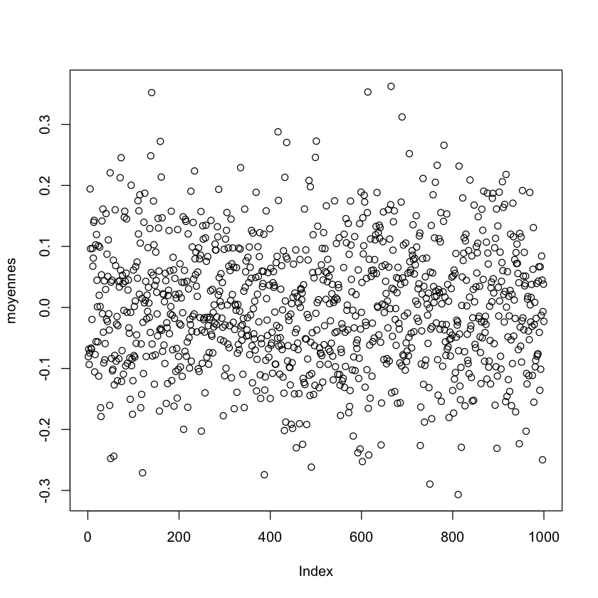

```r
moyennes<-NULL
for (i in 1:1000){
    mu<-mean(rnorm(100))
    moyennes<-rbind(moyennes, mu)
}
plot(moyennes)
```

Toutefois, cette manière n'est pas la plus optimale en termes de temps de calcul. pour le prouver, utilisons la fonction `system.time()` afin de mesurer le temps d'exécution de la boucle précédente, mais cette fois sur 20000 valeurs.

```r
moyennes<-NULL
a<-system.time(
for (i in 1:20000){
    mu<-mean(rnorm(100))
    moyennes<-rbind(moyennes, mu)
}
)
a
```

```
   user  system elapsed
  3.953   0.107   4.063
```

## vectoriser pour accélerer

Au lieu de créer un objet `NULL` de taille et de type indéfini et d'y insérer le calcul via `rbind`, on peut créer un vecteur vide de même taille que le nombre de valeurs du résultat produit.

```r
moyennes<-numeric(length = 20000)
b<-system.time(
for (i in 1:20000){
    mu<-mean(rnorm(100))
    moyennes[i] <-mu
}
)
b
```

```
   user  system elapsed
  0.413   0.002   0.415
```

Ce qu'on vient de faire est génial! au lieu d'ajouter le résultat calculé à l'objet vide à chaque itération, nous assignons plutôt le résultat à l'index courant du **vecteur** vide.

Comparons les temps écoulés entre les deux manières de faire:

```r
round(a[3]/b[3],2)
```

[output not shown]

# Développer des fonctions

Dans les chapitres précédents, nous avons développé plusieurs exemples de code. Par exemple, nous avons calculé la valeur présente d'une série de paiements. Dans cette section, nous verrons qu'il est possible de faire ces mêmes calculs en se servant de nos propres fonctions. Creer des fonctions nous permet d'éviter de réécrire le code qui fait le même calcule à chaque fois.

Syntaxe:

```
{R}
NonDeFonction <- function(arg1, arg2, ...) {
    codeAexécuter
    return(resultatSouhaité)
}
```

prenons l'exemple classique où l'on crée une fonction qui additionne deux éléments;

```r
somme<-function(x,y){
    return(x+y)
}
```

Appliquons cette fonction maintenant:

```r
somme(2,3)
```

5

## Gestion de erreurs,

On peut éviter des erreurs d'exécution par le moyen de conditions. Toutesfois, cette solution nécessite une connaissance des erreurs qui peuvent survenir. Dans notre exemple d'adition de deux éléments, on peut demander au programme de vérifier si les éléments à additionner sont d'abord de type numérique;

```r
somme<-function(x,y){
    if(is.numeric(x) & is.numeric(y)){
        return(x+y)
    }else {
        print("veuillez vérifier vos arguments")
    }

}
```

```r
somme(2,2)
```

4

Toutefois, lorsqu'on essaie ceci:

```r
somme(2, "a")
```

```
[1] "veuillez vérifier vos arguments"
```

```r
operation<-function(x,y){
    if(is.numeric(x) & is.numeric(y)){
        return(c(x+y, x-y, x*y, x/y))
    }else {
        print("veuillez vérifier vos arguments")
    }
}
```

```r
operation(2,3)
```

1. 5

2. -1

3. 6

4. 0.666666666666667

## Résultat en plusieurs éléments (`list`)

Au lieu d'utiliser `return`, on peut utiliser `list` afin d'avoir une liste d'éléments dans le résultat. L'avantage d'avoir une liste est bien sûr la manipulation d'élément de cette dernière.

```r
operation_l<-function(x,y){
    if(is.numeric(x) & is.numeric(y)){
        list(x+y, x-y, x*y, x/y)
    }else {
        print("veuillez vérifier vos arguments")
    }
}
```

```r
resultat_sousForme_liste<-operation_l(2,3)
resultat_sousForme_liste
```

1. 5

2. -1

3. 6

4. 0.666666666666667

Ainsi, on peut extraire **un seul** (ou plusieurs) élément de notre liste résultante;

```r
resultat_sousForme_liste[2]
```

1. -1

Au lieu d'insérer deux éléments comme argument de notre fonction `operation_l`, insérons deux vecteurs et regardons la différence entre le résultat de la fonction `operation_l` et la fonction `operation`

```r
xvec<-c(1:5)
yvec<-c(6:10)
operation_l(xvec, yvec)
```

1. 1. 7

   2. 9

   3. 11

   4. 13

   5. 15

2. 1. -5

   2. -5

   3. -5

   4. -5

   5. -5

3. 1. 6

   2. 14

   3. 24

   4. 36

   5. 50

4. 1. 0.166666666666667

   2. 0.285714285714286

   3. 0.375

   4. 0.444444444444444

   5. 0.5

Maintenant, appliquons la fonction `operation` sur les mêmes vecteurs et inspectons à nouveau le résultat:

```r
operation(xvec, yvec)
```

1. 7

2. 9

3. 11

4. 13

5. 15

6. -5

7. -5

8. -5

9. -5

10. -5

11. 6

12. 14

13. 24

14. 36

15. 50

16. 0.166666666666667

17. 0.285714285714286

18. 0.375

19. 0.444444444444444

20. 0.5

Si l'on voulait par exemple extraire le deuxième élément de la liste, qui est le résultat de la soustraction dans notre exemple, il est plus difficile de le faire avec la fonction `operation`.

```r
operation_l(xvec, yvec)[2]
```

1. 1. -5

   2. -5

   3. -5

   4. -5

   5. -5

au lieu de:

```r
operation(xvec, yvec)[6:10]
```

1. -5

2. -5

3. -5

4. -5

5. -5

Où il est nécessaire de connaitre les index du seul vecteur résultant.

## inspecter la fonction:

On peut inspecter le code de notre fonction en inscrivant le nom de cette dernière. Surtout, lorsque le code de la fonction est perdu quelque part dans un autre code 100 lignes plutôt.

### le code

```r
operation_l
```

```
function (x, y)
{
    if (is.numeric(x) & is.numeric(y)) {
        list(x + y, x - y, x * y, x/y)
    }
    else {
        print("veuillez vérifier vos arguments")
    }
}
```

### les arguments de la fonction

On peut obtenir les arguments d'une fonction avec l'instruction suivante;

```r
formals(operation_l)
```

[output not shown]

### Les arguments par défaut

Il convient souvent de donner des arguments par défaut à notre fonction créée. Dans notre exemple `operation_l`, on pourrait données les valeurs `(x,y)={1,1}` afin d'éviter des division par `0` par exemple;

```r
operation_l<-function(x=1,y=1){
    if(is.numeric(x) & is.numeric(y)){
        list(x+y, x-y, x*y, x/y)
    }else {
        print("veuillez vérifier vos arguments")
    }
}
```

Lorsqu'on écrit la fonction sans aucun argument;

```r
operation_l()
```

1. 2

2. 0

3. 1

4. 1

On obtient le résultat de nos valeurs par défaut

## Best practice

Il est très conseillé de bien documenter les fonctions que vous créez. Cela vous aide lorsque vous revisez ou corrigez votre code. Sans oublier que la bonne documentation aide la personne qui relie votre code à bien comprendre ce que vous voulez avoir comme résultat. Que ce soit dans un contexte académique (travaux, examen....etc.) Et surtout dans le contexte professionnel, où les codes sont plus longs et plus lourds à lire lorsque la documentation est quasi absente.

```r
operation_l<-function(x=1,y=1){
  # Cette fonction calcule l'adition, soustraction, multiplication
  # ainsi que la division de deux vecteurs
  # Args:
  #   x: La valeur du premier vecteur, la valeur par défaut étant =1
  #   y: La valeur du deuxième vecteur, la valeur par défaut étant =1
  #
  # retourne:
  #   une liste du résultat des opérations ....

    if(is.numeric(x) & is.numeric(y)){
        list(x+y, x-y, x*y, x/y)
    }
    # Gestion d'erreurs
    else {
        print("veuillez vérifier vos arguments")
    }
}
```

# Sauvege d'objets

Il possible de sauvegarder tout objet sous format `.RData`. Il convient de faire cette sauvegarde lorsque nous ne voulons pas garder nos objets en mémoire. Surtout, lorsque nous travaillons avec des données importantes en volume.

```r
x<-matrix(rnorm(100), ncol=10)
```

```r
save(x, file = "x.RData")
```

Maintenant, on peut recharger ces mêmes données. pour être sûr que nous n'avons pas chargé les données qui étaient en mémoire, supprimons tout ce qui se retrouve dans l'environnement:

```r
rm(list=ls())
```

```r
load("x.RData")
```

```r
x
```

| 1.18939619 | 0.01057899 | -0.35654252 | 1.65102435 | -1.3475614 | -0.70525999 | 0.12251689 | -1.9915918 | -0.3322830 | 1.02455290 |
| --- | --- | --- | --- | --- | --- | --- | --- | --- | --- |
| -0.06534286 | 1.42791869 | 0.87576387 | -1.04904302 | -1.2970706 | -0.54152388 | 1.24576523 | 0.6561742 | -0.4844493 | -0.39839616 |
| -1.10988733 | 0.40814513 | -0.98567474 | 0.07558152 | -0.1571415 | 0.09037718 | -0.56200895 | -0.4960402 | -1.2550586 | -0.07348674 |
| 0.67465672 | 0.84057229 | -0.03364994 | 1.78939415 | 0.9036412 | 0.13285054 | 0.72001113 | 1.5614279 | -1.2266363 | 1.71525509 |
| 3.34160414 | -0.47974054 | -0.67199908 | 0.85596379 | 0.1871276 | -0.34076899 | 0.05979965 | -0.7835429 | 1.0479630 | 0.08575501 |
| -1.79255793 | -0.99787722 | 2.70522950 | 1.60416877 | -1.1513655 | 0.54021006 | -0.65092374 | 0.7824136 | 1.4823115 | 0.63362158 |
| -0.16944079 | 1.25588922 | -0.12954850 | 0.37858396 | -0.3957809 | 0.80730431 | 0.29098695 | -1.0314703 | -2.5441580 | -1.20221796 |
| 0.90407239 | -0.27608180 | -0.08992006 | -0.23410372 | -1.6570973 | -1.59602886 | 0.62270556 | 0.4811070 | -0.2526573 | 1.77087313 |
| 0.65195276 | -0.54867528 | 1.46378626 | 0.59448827 | -0.9709800 | -0.93753977 | -0.05390880 | 0.7824050 | -0.1869861 | -1.14069893 |
| 1.74168331 | 0.18004910 | 0.11510721 | -0.59757236 | -0.2167422 | -0.01264427 | 1.09123924 | -0.8519077 | -1.7291689 | 0.05694140 |

Il aussi possible de sauvegarder les données (les résultats par exemple) dans des fichiers `.csv` qu'on pourrait redistribuer par la suite dans le contexte de production de rapport ou de partage de résultats.

Nous utilisons alors la fonction `write.csv`;

```r
write.csv(x, "/Users/nour/Downloads/données_x.csv")
```

Remarquez qu'à chaque fois nous réexécutons ce code, nous supprimons l'ancien fichier portant le même nom.

On peut aussi lire ce même fichier avec la fonction

```r
oo<-read.csv("/Users/nour/Downloads/données_x.csv")
```

```r
head(oo)
```

| X | V1 | V2 | V3 | V4 | V5 | V6 | V7 | V8 | V9 | V10 |
| --- | --- | --- | --- | --- | --- | --- | --- | --- | --- | --- |
| 1 | 1.18939619 | 0.01057899 | -0.35654252 | 1.65102435 | -1.3475614 | -0.70525999 | 0.12251689 | -1.9915918 | -0.3322830 | 1.02455290 |
| 2 | -0.06534286 | 1.42791869 | 0.87576387 | -1.04904302 | -1.2970706 | -0.54152388 | 1.24576523 | 0.6561742 | -0.4844493 | -0.39839616 |
| 3 | -1.10988733 | 0.40814513 | -0.98567474 | 0.07558152 | -0.1571415 | 0.09037718 | -0.56200895 | -0.4960402 | -1.2550586 | -0.07348674 |
| 4 | 0.67465672 | 0.84057229 | -0.03364994 | 1.78939415 | 0.9036412 | 0.13285054 | 0.72001113 | 1.5614279 | -1.2266363 | 1.71525509 |
| 5 | 3.34160414 | -0.47974054 | -0.67199908 | 0.85596379 | 0.1871276 | -0.34076899 | 0.05979965 | -0.7835429 | 1.0479630 | 0.08575501 |
| 6 | -1.79255793 | -0.99787722 | 2.70522950 | 1.60416877 | -1.1513655 | 0.54021006 | -0.65092374 | 0.7824136 | 1.4823115 | 0.63362158 |